# Arbeitspaket (AP) 3: Multimodal Interactions - Images

### Persönliche Angaben (bitte ergänzen)

| Vorname: | Andrin |
| --- | --- |
| Nachname: | Gloor |
| Immatrikulationsnummer: | 20-649-810 |
| Modul: | Data Science |
| Prüfungsdatum / Raum / Zeit: | 15.12.2025 / Raum: MU O2.001 / 8:00 – 11:45 |
| Erlaubte Hilfsmittel: | w.MA.XX.DS.24HS (Data Science) Open Book, Eigener Computer, Internet-Zugang |
| Nicht erlaubt: | Nicht erlaubt ist der Einsatz beliebiger Formen von generativer KI (z.B. Copilot, ChatGPT) sowie beliebige Formen von Kommunikation oder Kollaboration mit anderen Menschen. |

## Bewertungskriterien

| **Kategorie** | **Beschreibung** | **Punkteverteilung** |
| --- | --- | --- |
| **Code nicht lauffähig oder Ergebnisse nicht relevant** | Der Code läuft nicht oder erfüllt nicht die Anforderungen des Aspekts (z. B. Bilder werden nicht geladen, die Textausgabe der Extraktion fehlt, Bounding Boxes werden nicht angezeigt). | **0 Punkte** |
| **Code lauffähig, aber mit gravierenden Mängeln** | Der Code läuft, jedoch fehlen zentrale Teile der Funktionalität eines Aspekts (z. B. unvollständige Extraktion von Bildinformationen oder Fehler bei der Definition eines Schemas). | **25% der max. erreichbaren Punkte** |
| **Code lauffähig, aber mit mittleren Mängeln** | Der Code läuft und liefert teilweise korrekte Ergebnisse für einen Aspekt, aber wichtige Details fehlen (z. B. ungenaue Bounding Boxes, unvollständige Integration der extrahierten Daten). | **50% der max. erreichbaren Punkte** |
| **Code lauffähig, aber mit minimalen Mängeln** | Der Code erfüllt die Anforderungen eines Aspekts weitgehend, aber kleinere Fehler oder Abweichungen (z. B. nicht robust Extraktionsdaten, kleinere Schemaabweichungen, Prompt zu wenig stringent formuli… | **75% der max. erreichbaren Punkte** |
| **Code lauffähig und korrekt** | Der Code erfüllt die Anforderungen des Aspekts vollständig und liefert die erwarteten Ergebnisse ohne Fehler (z. B. korrekte Extraktion, vollständige Bounding Boxes, saubere Integration). | **100% der max. erreichbaren Punkte** |

## **Vorbereitung (Dieser Teil wird nicht bewertet!)**

#### **1.) Starten Sie eine GitHub Codespaces Instanz auf Basis Ihres Forks des folgenden GitHub Repositories:**

##### GitHub-Repository: https://github.com/zhaw-iwi/MultimodalInteraction_ObjDet

#### **2.) Erstellen Sie eine neue Datei .env in Ihrem Codespace, die die API-Keys als ENV-Variabel enthält, und laden Sie diese in Ihrem Code mithilfe der dotenv Library.**

## **Aufgaben (Dieser Teil wird bewertet!)**

### **Hinweise zum folgenden Arbeitspaket:**

Im Rahmen dieses Arbeitspakets sollen Sie eine kombinierte Text- und Objekterkennung durchführen, um mithilfe von Textinformationen Inhalte aus Bildern zu extrahieren. Ihnen stehen dabei eine schriftliche Rezeptbeschreibung sowie zwei Bilder zur Verfügung:  
**`pizza_recipe.txt`**, **`home_ingredients_list.png`** und **`supermarket_shelf.png`**.

- **`pizza_recipe.txt`** enthält ein schriftliches Rezept für eine Pizza mit einer Liste aller benötigten Zutaten.
- **`home_ingredients_list.png`** zeigt eine handgeschriebene Notiz mit den Zutaten, die bereits zu Hause vorhanden sind.
- **`supermarket_shelf.png`** zeigt ein Regal in einem Supermarkt mit verschiedenen Lebensmitteln.

Stellen Sie sich vor, Sie entwickeln nun ein Programm für einen Einkaufs- bzw. Küchenassistenz-Roboter, der hypothetisch automatisch erkennt, welche Zutaten für das Rezept noch fehlen und diese im Supermarktregal lokalisieren kann. Verwenden Sie die bereitgestellten Dateien als Informationsquelle.

**Erwartetes Ergebnis:**  
Das Programm sollte zunächst den Text aus **`home_ingredients_list.png`** in strukturierter Form extrahieren und mit den im Rezept **`pizza_recipe.txt`** aufgeführten Zutaten vergleichen. Daraus sollen die fehlenden Zutaten identifiziert werden. Anschliessend soll das Programm im Bild **`supermarket_shelf.png`** die fehlenden Zutaten lokalisieren und die Koordinaten der entsprechenden Begrenzungsrahmen (Bounding Boxes) ausgeben.  
Zeichnen Sie für jede fehlende, im Regal vorhandene Zutat eine Bounding Box direkt in **`supermarket_shelf.png`** ein und visualisieren Sie das Bild.

**Einreichungsdokumente:**  
Die Einreichung dieser Aufgabe sollte Folgendes umfassen:

- Das von Ihnen bearbeitete Notebook (dieses File).

**Generelle Hinweise:**

- Beachten Sie auch die zu jeder Aufgabenstellung zugehörenden Details zur Aufgabenstellung.
- Lösen Sie jede Aufgabe mit Hilfe von Python Code. Integrieren Sie den Python Code in die Code-Zellen der jeweiligen Aufgabe.
- Stellen Sie sämtliche von Ihnen erstellte Ergebnisse inklusive Grafiken im Jupyter Notebook dar.

## Utils (Hilfsfunktionen):

Hier finden Sie einige vorgefertigte Funktionen, die Ihnen helfen, Bounding Boxes zu visualisieren und zu plotten sowie verschiedene Arten von Output zu parsen. Sie könnten Diese benutzen oder neue Funktionen selbst erstellen, falls notwendig.

```python
import json
import re
from PIL import Image, ImageDraw
from PIL import ImageColor

additional_colors = [colorname for (colorname, colorcode) in ImageColor.colormap.items()]

#this function is needed to plot bounding boxes on images
def plot_bounding_boxes(im, positions):
    """
    Plots bounding boxes on an image with markers for each noun phrase, using PIL, normalized coordinates, and different colors.

    Args:
        img_path: The path to the image file.
        noun_phrases_and_positions: A list of tuples containing the noun phrases
         and their positions in normalized [y1 x1 y2 x2] format.
    """

    # Load the image
    img = im
    width, height = img.size
    print(img.size)
    # Create a drawing object
    draw = ImageDraw.Draw(img)

    # Define a list of colors
    colors = [
    'red',
    'green',
    'blue',
    'yellow',
    'orange',
    ] + additional_colors

    # Iterate over the noun phrases and their positions
    for i, ((y1, x1, y2, x2)) in enumerate(positions):
        # Select a color from the list
        color = colors[i % len(colors)]

        # Convert normalized coordinates to absolute coordinates
        abs_x1 = int(x1/1000 * width)
        abs_y1 = int(y1/1000 * height)
        abs_x2 = int(x2/1000 * width)
        abs_y2 = int(y2/1000 * height)

        # Draw the bounding box
        draw.rectangle(
            ((abs_x1, abs_y1), (abs_x2, abs_y2)), outline=color, width=4
        )

        # Draw the text
        #draw.text((abs_x1 + 8, abs_y1 + 6), noun_phrase, fill=color)

    # Display the image
    img.show()

# if the boxes coordinates are output not as json but as text, should be parsed first
def parse_list_boxes(text):
  result = []
  for line in text.strip().splitlines():
    # Extract the numbers from the line, remove brackets and split by comma
    try:
      numbers = line.split('[')[1].split(']')[0].split(',')
    except:
      numbers =  line.split('- ')[1].split(',')

    # Convert the numbers to integers and append to the result
    result.append([int(num.strip()) for num in numbers])

  return result

def parse_json_in_output(output):
    """
    Extracts and converts JSON-like data from the given text output to a Python dictionary.

    Args:
        output (str): The text output containing the JSON data.

    Returns:
        dict: The parsed JSON data as a Python dictionary.
    """
    # Regex to extract JSON-like portion
    json_match = re.search(r"\{.*?\}", output, re.DOTALL)
    if json_match:
        json_str = json_match.group(0)
        # Fix single quotes and ensure proper JSON formatting
        json_str = json_str.replace("'", '"')  # Replace single quotes with double quotes
        try:
            # Convert the fixed JSON string into a dictionary
            json_data = json.loads(json_str)
            return json_data
        except json.JSONDecodeError:
            return "The extracted JSON is still not valid after formatting."
    else:
        return "No JSON data found in the given output."
```

### **Aufgabe (1): Laden von Daten / Import der notwendigen Libraries**

**Details zur Aufgabenstellung:**

- Importieren Sie hier alle notwendigen Python-Libraries, die Sie für die späteren Aufgaben benötigen.
- Initialisieren Sie die benötigten Clients für die verwendeten VLM-Modelle.
- Definieren Sie für die Bilder **`home_ingredients_list.png`** und **`supermarket_shelf.png`** (z.B. im Ordner `Data/`) jeweils eine Variable, die den Pfad zur Datei enthält.
- Laden Sie ausserdem den Inhalt der Textdatei **`pizza_recipe.txt`** (z.B. aus dem Ordner `Data/`) in eine String-Variable, damit das Rezept in späteren Aufgaben weiterverwendet werden kann (s. Hinweis)

**(max. erreichbare Punkte: 6)**

```python
%matplotlib inline
from dotenv import load_dotenv
from google import genai
from PIL import Image

load_dotenv()
client = genai.Client()
```

```python
import openai
from dotenv import load_dotenv
import base64
import json
import textwrap

# Function to encode the image
def encode_image(image_path):
  with open(image_path, "rb") as image_file:
    return base64.b64encode(image_file.read()).decode('utf-8')
```

```python
#im = Image.open("images/prescription1.jpg")  # Bilddatei öffnen

pfad_home = "Data/home_ingredients_list.png"
pfad_super = "Data/supermarket_shelf.png"

homel = Image.open(pfad_home)  # Bilddatei öffnen
superm = Image.open(pfad_super)  # Bilddatei öffnen
print(homel)
```

```
<PIL.PngImagePlugin.PngImageFile image mode=RGB size=1024x1536 at 0x710D6B1EF130>
```

```python
file_path = "Data/pizza_recipe.txt"

with open(file_path, 'r') as file:
    file_content = file.read()

print(file_content)
```

```
"To make a simple pizza, first mix flour, a teaspoon of dry yeast and a spoonful of oil into a soft dough, knead it for a few minutes, then let it rest until it puffs up. When it has risen, heat the oven to about 220°C, stretch the dough into a thin round on a floured tray, and spread a layer of tom…
```

```python
# Hinweis: Um ein .txt file in einer string variable zu laden benutzen Sie diese Syntax - PATH_TO_YOUR_TXT_FILE anpassen

#with open("PATH_TO_YOUR_TXT_FILE", "r", encoding="utf-8") as f:
#    pizza_recipe_text = f.read()
```

### **Aufgabe (2): Definition eines strukturierten Schemas für die Extraktion von Informationen**

Details zur Aufgabenstellung:

- Definierien Sie ein strukturiertes Schema (z. B. ein JSON-Schema), um die Informationen aus dem Bild `home_ingredients_list.png` zu organisieren. Das Schema sollte die Felder und die Struktur klar definieren, die für die Darstellung der extrahierten Daten erforderlich sind.

**(max. erreichbare Punkte: 6)**

```python
json_schema = {
  "name": "ingredient_extraction",
  "schema": {
    "type": "object",
    "properties": {
      "ingredients": {
        "type": "array",
        "items": {
          "type": "object",
          "properties": {
            "name": { "type": "string" },
            "category": { "type": "string" }
          },
          "required": ["name"]
        }
      }
    },
    "required": ["ingredients"]
  }
}
```

### **Aufgabe (3): Extraktion von visuellen Informationen mittels Prompting**

**Details zur Aufgabenstellung:**

- Extrahieren Sie strukturierte visuelle Informationen aus dem Bild **`home_ingredients_list.png`** mithilfe von textualem Prompting unter Verwendung des Modells **GPT-4.1-mini**.
- Die Extraktion soll dem zuvor definierten **JSON-Schema** für Zutatenlisten folgen.
- Laden Sie anschlieend die vom Modell ausgegebene JSON-Struktur in ein entsprechendes **Python Dictionary**, um sie für die weiteren Arbeitsschritte weiterzuverarbeiten.
- Ziel ist es, alle im Bild enthaltenen Zutaten vollständig und strukturiert auszulesen, sodass diese später mit dem Rezept verglichen werden können.

**(max. erreichbare Punkte: 12)**

```python
import openai
from dotenv import load_dotenv
import base64
import json
import textwrap

# Function to encode the image
def encode_image(image_path):
  with open(image_path, "rb") as image_file:
    return base64.b64encode(image_file.read()).decode('utf-8')  # Bildbytes → Base64 kodieren


load_dotenv()  # lädt Variablen aus .env
openAIclient = openai.OpenAI()  # API-Client initialisieren


# Path to your image
img = "Data/home_ingredients_list.jpg"
```

```python
ompletion = openAIclient.chat.completions.create(
    model="gpt-4.1-mini",
    messages=[
        {"role": "system", "content": "you are a careful observer. the response should be in json format"},
        {"role": "user", "content": [
                {"type": "text", "text": "Describe the image in detail"},
                {
                    "type": "image_url",
                    "image_url": {
                        "url": f"data:…)}",
                        #"detail": "low"
                    }
                },
            ]}
    ],
    response_format={
                "type": "json_schema",
                "json_schema": {
  "name": "ingredient_extraction",
  "schema": {
    "type": "object",
    "properties": {
      "ingredients": {
        "type": "array",
        "items": {
          "type": "object",
          "properties": {
            "name": { "type": "string" },
            "category": { "type": "string" }
          },
          "required": ["name"]
        }
      }
    },
    "required": ["ingredients"]
  }
}},
    temperature = 0
)

returnValue = completion.choices[0].message.content
```

```python
returnValue
```

[output not shown]

```python
output_image_extraction = json.loads(returnValue)
```

```python
output_image_extraction["ingredients"]
```

[output not shown]

```python
output = json.loads(returnValue)
#json. loads() converts JSON strings to Python objects
print(output)
```

[output not shown]

```python
list(output.keys())
```

[output not shown]

```python
completion = openAIclient.chat.completions.create(
    model="gpt-4.1-mini",
    messages=[
        {"role": "system", "content": "you are a careful observer. the response should be in json format"},
        {"role": "user", "content": [
                {"type": "text", "text": "Describe the image in detail"},
                {
                    "type": "image_url",
                    "image_url": {
                        "url": f"data:…)}",
                        #"detail": "low"
                    }
                },
            ]}
    ],
    response_format={ "type": "json_object" },# NEW!!
    temperature = 0
)

returnValue = completion.choices[0].message.content
```

```python
returnValue
```

```
'{\n  "title": "What we have already at home",\n  "items": [\n    "olives",\n    "ham",\n    "flour",\n    "mozzarella",\n    "oil",\n    "oregano",\n    "yeast"\n  ],\n  "description": "The image shows a handwritten list on a beige or light brown paper background. The title \'What we have already a…
```

```python
output = json.loads(returnValue)
#json. loads() converts JSON strings to Python objects
print(output)
```

[output not shown]

### **Aufgabe (4): Integration der extrahierten Daten in neuem Prompt für die Identifizierung fehlender Zutaten**

**Details zur Aufgabenstellung:**

- Verwenden Sie **GPT-4.1-mini**, um anhand eines Prompts, der den Rezepttext aus **`pizza_recipe.txt`** (als String) sowie die zuvor extrahierte JSON-Struktur aus Aufgabe 3 **direkt aus den entsprechenden Python-Variablen** enthält, zu bestimmen, welche Zutaten für das Rezept noch fehlen.
- Die Informationen sollen **nicht manuell übertragen oder abgeschrieben**, sondern programmgesteuert in den Prompt integriert werden.
- Das Modell soll ausschließlich die Zutaten identifizieren, die nicht in der Haushaltsliste enthalten sind, und diese eindeutig benennen.
- Die Ausgabe soll eine klar strukturierte, weiterverarbeitbare Form besitzen (mind. "json_object" in response_format).

**(max. erreichbare Punkte: 12)**

```python
list(output.keys())
```

[output not shown]

```python
#alert service prompt

alert_sys_prompt = " you are an experienced pizzailo"
alert_prompt= """Look at the list in JSON format. Those are the ingredients you have at home, and here in the string file is the recipe.
Compare them and tell me what's missing.
 """ + str(file_content) + "\n" + str(output)
```

```python
completion = openAIclient.chat.completions.create(
    model="gpt-4.1-mini",
    messages=[
        {"role": "user", "content": alert_prompt},
        {"role": "user", "content": alert_prompt}
    ],
)


# Wrap the text to a specified width

response = str(completion.choices[0].message.content)
print(textwrap.fill(response, width=120))
```

```
Comparing the recipe ingredients with what you have at home:  **Recipe needs:** - Flour - Dry yeast - Oil - Tomato sauce
- Mozzarella - Ham - Olives - Oregano  **You have at home:** - Olives - Ham - Flour - Mozzarella - Oil - Oregano - Yeast
**Missing ingredient:** - Tomato sauce  So, the only missing ingredient from your list to make the pizza as per the
recipe is **tomato sauce**.
```

### **Aufgabe (5): Lokalisierung der fehlenden Zutaten im Supermarktregal**

**Details zur Aufgabenstellung:**

- Verwenden Sie das Modell **Gemini-2.5-Flash**, um die in Aufgabe 4 ermittelte Liste der fehlenden Zutaten im Bild **`supermarket_shelf.png`** zu lokalisieren.
- Die Liste der fehlenden Zutaten soll **automatisch aus der entsprechenden Python-Variable** in den Prompt eingebunden werden; sie darf nicht manuell in den Prompt kopiert werden.
- Das Modell soll für jede im Regal vorhandene fehlende Zutat die **Bounding-Box-Koordinaten** extrahieren.

**(max. erreichbare Punkte: 12)**

```python
%matplotlib inline
from dotenv import load_dotenv
from google import genai
from PIL import Image
import textwrap

import json

load_dotenv()
client = genai.Client()
```

```python
pfad_super = "Data/supermarket_shelf.png"

im = Image.open(pfad_super)


response = client.models.generate_content(
    model="gemini-2.5-flash",
    contents=[
        im,
        (
            "Detect if there is a piiza sauce in the image and reutrn its coordinates as a list in the format [ymin,xmin, ymax, xmax], normalize the coordinate to 0-1000. answer should be json format only"
        ),

    ],
    config={"response_mime_type": "application/json"}
)

print(response.text)
```

```
[
  {"box_2d": [307, 431, 442, 546], "label": "piiza sauce"}
]
```

```python
json.loads(response.text)
```

```
[{'box_2d': [307, 431, 442, 546], 'label': 'piiza sauce'}]
```

### **Aufgabe (6): Visualisierung von Bounding Boxes**

**Details zur Aufgabenstellung:**

- Verwenden Sie die in Aufgabe 5 berechneten Bounding-Box-Koordinaten, um die fehlenden Zutaten im Bild **`supermarket_shelf.png`** grafisch zu markieren.
- Plotten Sie alle Bounding Boxes auf das Bild und überprüfen Sie, ob die Lokalisierung der fehlenden Zutaten im Supermarktregal plausibel ist.

*Hinweis: In den Utils befinden sich Hilfsfunktionen, die Sie für das Zeichnen der Bounding Boxes verwenden können.*

**(max. erreichbare Punkte: 12)**

```python
#this function is needed to plot bounding boxes on images
def plot_bounding_boxes(im, positions):
    """
    Plots bounding boxes on an image with markers for each noun phrase, using PIL, normalized coordinates, and different colors.

    Args:
        img_path: The path to the image file.
        noun_phrases_and_positions: A list of tuples containing the noun phrases
         and their positions in normalized [y1 x1 y2 x2] format.
    """

    # Load the image
    img = im
    width, height = img.size
    print(img.size)
    # Create a drawing object
    draw = ImageDraw.Draw(img)

    # Define a list of colors
    colors = [
    'red',
    'green',
    'blue',
    'yellow',
    'orange',
    ] + additional_colors

    # Iterate over the noun phrases and their positions
    for i, ((y1, x1, y2, x2)) in enumerate(positions):
        # Select a color from the list
        color = colors[i % len(colors)]

        # Convert normalized coordinates to absolute coordinates
        abs_x1 = int(x1/1000 * width)
        abs_y1 = int(y1/1000 * height)
        abs_x2 = int(x2/1000 * width)
        abs_y2 = int(y2/1000 * height)

        # Draw the bounding box
        draw.rectangle(
            ((abs_x1, abs_y1), (abs_x2, abs_y2)), outline=color, width=4
        )

        # Draw the text
        #draw.text((abs_x1 + 8, abs_y1 + 6), noun_phrase, fill=color)

    # Display the image
    img.show()

# if the boxes coordinates are output not as json but as text, should be parsed first
def parse_list_boxes(text):
  result = []
  for line in text.strip().splitlines():
    # Extract the numbers from the line, remove brackets and split by comma
    try:
      numbers = line.split('[')[1].split(']')[0].split(',')
    except:
      numbers =  line.split('- ')[1].split(',')

    # Convert the numbers to integers and append to the result
    result.append([int(num.strip()) for num in numbers])

  return result
```

```
(1024, 1536)
```

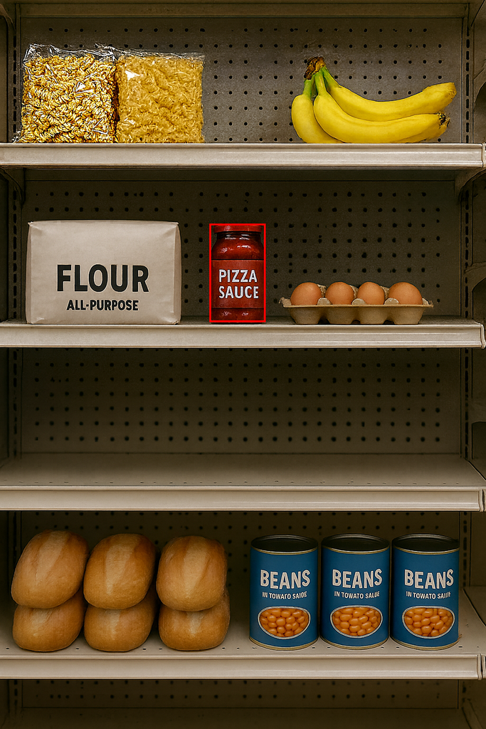

```python
#boxes= parse_list_boxes(response.text) # same comment as above
box_coord = [json.loads(response.text)[0]['box_2d']] #due to the fact it is a list, otherwise this line might change
plot_bounding_boxes(im,positions=list(box_coord))
```

Ist die Visualisierung korrekt? Sonst überprüfen Sie die Outputs vorher.

### Jupyter notebook --footer info-- (please always provide this at the end of each notebook)

```python
import os
import platform
import socket
from platform import python_version
from datetime import datetime

print('-----------------------------------')
print(os.name.upper())
print(platform.system(), '|', platform.release())
print('Datetime:', datetime.now().strftime("%Y-%m-%d %H:%M:%S"))
print('Python Version:', python_version())
print('IP Address:', socket.gethostbyname(socket.gethostname()))
print('-----------------------------------')
```

```
-----------------------------------
POSIX
Linux | 6.8.0-1030-azure
Datetime: 2025-12-15 10:16:51
Python Version: 3.10.19
IP Address: 127.0.0.1
-----------------------------------
```